# Week 3 Association Rule Mining

31 January, 2020

## Overview of Topics

- Basic concepts
- Transactional dataset, itemset and association rules
- Metrics to evaluate quality of association rules
- Aprior algorithm to derive frequent itemsets and generate association rules
- Association rule mining demo in R and Python

## Motivation

- Sift through large size of transactional database (a.k.a Market Basket Dataset)
  - Each record is a transaction
- Identify those items which are most likely to co-occur in an efficient way
  - A Priori principle
  - Rule generation heuristic
- Output findings as Association Rules
  - {Antecedent} -> {Consequent}
  - If…Then…

## Application Examples

- Could be used for both supervised and unsupervised purpose
  - For unsupervised learning purpose, search for interesting data co-occurrence patterns
  - For supervised learning purpose, force the target classification attribute on the Right Hand Side (RHS)
- Finding behavioral patterns of credit card usage that occur in combination with fraudulent case
- Searching for interesting or frequently occurring patterns of DNA in cancer patients
- E-Commerce recommender system: recommend new items based on consumer’s shopping history

## Market Basket Data

- Transactional dataset examples

| ID | Transactions |
| --- | --- |
| 10001 | banana, milk, beer, diaper |
| 10002 | milk, diaper, beer, chicken, apple |
| 10003 | diaper, beer, orange, cheese |
| 10004 | beer, chicken, orange |
| 10005 | cheese, orange, milk, apple, cereal, egg |
| … | … |

## Derive Association Rules from Market Basket Data

- Item, itemset, length of itemset
  - {banana, milk, beer}: length = 3
- Association rules:
  - {banana} => {milk}, {beer, egg} => {diaper}
  - How to evaluate quality of the association rules?
    - Frequency of the association
    - Strength of the association

## Key Evaluation Metrics

- Support \[ support(X) = \frac{count(X)}{N} \]
- Confidence \[ confidence(X \rightarrow Y) = \frac{support(X, Y)}{support(X)} \]
- Lift \[ lift(X \rightarrow Y) = \frac{support(X, Y)}{support(X)support(Y)} =\frac{confidence(X \rightarrow Y)}{support(Y)} \]

## Properties of Performance Metrics

- Support: How often can the association rule be applied?
- Confidence: Strength of the rules
  - How often Y co-occurs with X
  - Asymmetric: direction of rule makes difference
- Lift: normalized confidence
  - If X and Y are independent, lift = 1
  - If X and Y tend to occur together, lift > 1
  - If X and Y tend *NOT* to occur together, lift < 1
  - similarity to correlation
  - Symmetric (direction doesn’t make any difference)
  - Potential issue: order between items, such as {buy iphone} \(\rightarrow\) {buy earphone}
- Range and critical values of the above metrics

## Two-Steps to Mine Association Rules

- Frequent Itemset Generation
  - Generate all itemsets with support \(\geq\) min_sup
  - More computational intensive step
  - A Priori principle: if an itemset is found to be *NOT* frequent, there is no need to further expand such itemset
- Rule Generation
  - Generate high confidence rules from each frequent itemset by doing binary partition of frequent itemsets
  - Heuristic: if an association rule’s confidence is not high enough, no needs to further explore all other association rules from the same frequent itemset which have a larger RHS

## Apriori Algorithm to Derive Frequent Itemsets

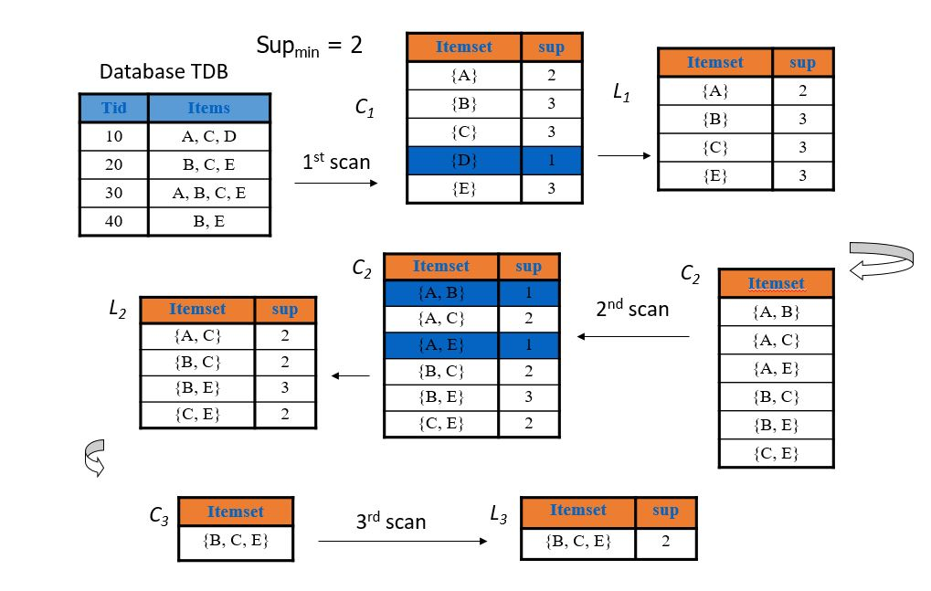

## Rule Generation Heuristic

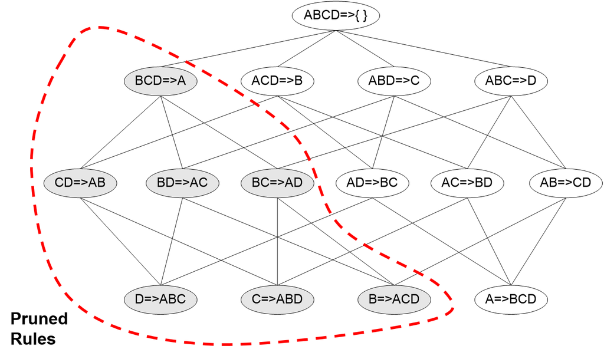

## Limitations of Association Rule Mining

- Illustrate association but not causation
  - {guy, diaper} -> {beer} doesn’t necessarily mean buying diaper *directly caused* buying beer for a guy; it only means a guy buying diaper is more likely to buy beer than a random guy
- Can only work with categorical attributes.
  - Need to discretize all numerical attributes in pre-processing
- Can’t deal with categorical attributes with large number of possible values which lead to low support association rules
  - Perform data exploration to check distribution of attributes and collapse those attribute values with low counts
- Iterative model parameter tuning process
  - Too many discovered rules: increase metric cutoffs in parameter setting
  - Obtaining non interesting rules: domain knowledge

## Demo Dataset: [AdultUCI](https://archive.ics.uci.edu/ml/datasets/adult)

```r
library(arules)
library(arulesViz)
data("AdultUCI")
str(AdultUCI)
```

```
## 'data.frame':    48842 obs. of  15 variables:
##  $ age           : int  39 50 38 53 28 37 49 52 31 42 ...
##  $ workclass     : Factor w/ 8 levels "Federal-gov",..: 7 6 4 4 4 4 4 6 4 4 ...
##  $ fnlwgt        : int  77516 83311 215646 234721 338409 284582 160187 209642 45781 159449 ...
##  $ education     : Ord.factor w/ 16 levels "Preschool"<"1st-4th"<..: 14 14 9 7 14 15 5 9 15 14 ...
##  $ education-num : int  13 13 9 7 13 14 5 9 14 13 ...
##  $ marital-status: Factor w/ 7 levels "Divorced","Married-AF-spouse",..: 5 3 1 3 3 3 4 3 5 3 ...
##  $ occupation    : Factor w/ 14 levels "Adm-clerical",..: 1 4 6 6 10 4 8 4 10 4 ...
##  $ relationship  : Factor w/ 6 levels "Husband","Not-in-family",..: 2 1 2 1 6 6 2 1 2 1 ...
##  $ race          : Factor w/ 5 levels "Amer-Indian-Eskimo",..: 5 5 5 3 3 5 3 5 5 5 ...
##  $ sex           : Factor w/ 2 levels "Female","Male": 2 2 2 2 1 1 1 2 1 2 ...
##  $ capital-gain  : int  2174 0 0 0 0 0 0 0 14084 5178 ...
##  $ capital-loss  : int  0 0 0 0 0 0 0 0 0 0 ...
##  $ hours-per-week: int  40 13 40 40 40 40 16 45 50 40 ...
##  $ native-country: Factor w/ 41 levels "Cambodia","Canada",..: 39 39 39 39 5 39 23 39 39 39 ...
##  $ income        : Ord.factor w/ 2 levels "small"<"large": 1 1 1 1 1 1 1 2 2 2 ...
```

## Data Pre-processing: Discretization

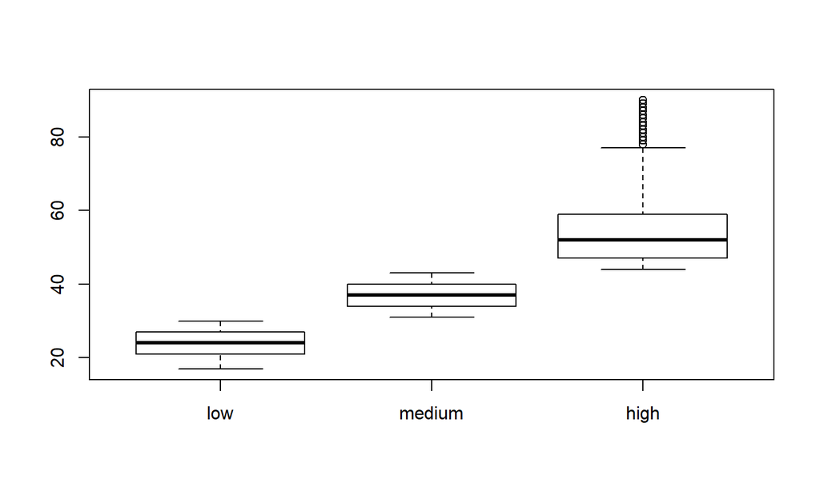

```r
var_to_discretize <- c("age", "hours-per-week")
AdultUCI$age_grp <- discretize(AdultUCI$age, method = "frequency", breaks = 3,
                               labels = c("low", "medium", "high"), order = T)
boxplot(age ~ age_grp, data = AdultUCI)
```

## Mining Association with Apriori

```r
apriori(data, parameter = NULL, apearance = NULL, control = NULL)
```

- Parameter: named list with default settings
  - support/supp: minimal support of a rule (default: 0.1)
  - confidence/conf: minimal confidence of association rules (default: 0.8)
  - minlen: an integer for the mininal number of items per rule (default: 1)
  - maxlen: an integer for the maxiaml number of items per rule (default: 10)
- Apriori only creates rules with one item in the RHS (Consequent)
  - Need to set minlen = 2 if you don’t want a rule like {} => {beer} with empty antecedent/LHS

## Approach 1: Run A Priori Against Record Dataset Directly

```r
rules_record <- apriori(AdultUCI[, sapply(AdultUCI, is.factor)],
                 parameter = list(support = 0.1, confidence = 0.5, minlen = 3))
```

```r
inspect(head(rules_record, 5))
```

```
##     lhs                               rhs                              support confidence     lift count
## [1] {occupation=Exec-managerial,
##      race=White}                   => {native-country=United-States} 0.1059539  0.9453782 1.053435  5175
## [2] {occupation=Exec-managerial,
##      native-country=United-States} => {race=White}                   0.1059539  0.9231181 1.079616  5175
## [3] {occupation=Craft-repair,
##      sex=Male}                     => {race=White}                   0.1076532  0.9082743 1.062256  5258
## [4] {occupation=Craft-repair,
##      race=White}                   => {sex=Male}                     0.1076532  0.9553052 1.429066  5258
## [5] {occupation=Craft-repair,
##      sex=Male}                     => {native-country=United-States} 0.1068138  0.9011919 1.004198  5217
```

## Approach 2: Run A Priori Against Transactional Dataset: Prepare a Transactional Dataset

- First convert the record dataset to a transational dataset, then apply A Priori algorithm.
  - Note difference between the converted transactional dataset (all transactionals with the same length) and a market basket dataset.
  - Not all the attributes have presence/absence value pairs unlike a market baset

```r
fac_var <- sapply(AdultUCI, is.factor)
adult <- as(AdultUCI[, fac_var], "transactions")
inspect(head(adult, 2))
```

```
##     items                               transactionID
## [1] {workclass=State-gov,
##      education=Bachelors,
##      marital-status=Never-married,
##      occupation=Adm-clerical,
##      relationship=Not-in-family,
##      race=White,
##      sex=Male,
##      native-country=United-States,
##      income=small,
##      age_grp=medium}                                1
## [2] {workclass=Self-emp-not-inc,
##      education=Bachelors,
##      marital-status=Married-civ-spouse,
##      occupation=Exec-managerial,
##      relationship=Husband,
##      race=White,
##      sex=Male,
##      native-country=United-States,
##      income=small,
##      age_grp=high}                                  2
```

## Approach 2: Run A Priori Against Transactional Dataset

```r
rules_transaction <- apriori(adult,
                             parameter = list(support = 0.1, confidence = 0.5, minlen = 3))
```

```r
inspect(head(rules_transaction, 5))
```

```
##     lhs                               rhs                              support confidence     lift count
## [1] {occupation=Exec-managerial,
##      race=White}                   => {native-country=United-States} 0.1059539  0.9453782 1.053435  5175
## [2] {occupation=Exec-managerial,
##      native-country=United-States} => {race=White}                   0.1059539  0.9231181 1.079616  5175
## [3] {occupation=Craft-repair,
##      sex=Male}                     => {race=White}                   0.1076532  0.9082743 1.062256  5258
## [4] {occupation=Craft-repair,
##      race=White}                   => {sex=Male}                     0.1076532  0.9553052 1.429066  5258
## [5] {occupation=Craft-repair,
##      sex=Male}                     => {native-country=United-States} 0.1068138  0.9011919 1.004198  5217
```

## Check and Visualize the Most Frequent Items

```r
frequent_items <- eclat(adult, parameter = list(support = 0.7, minlen = 2))
```

```r
inspect(head(frequent_items, 2))
```

```
##     items                                     support   count
## [1] {race=White,native-country=United-States} 0.7881127 38493
```

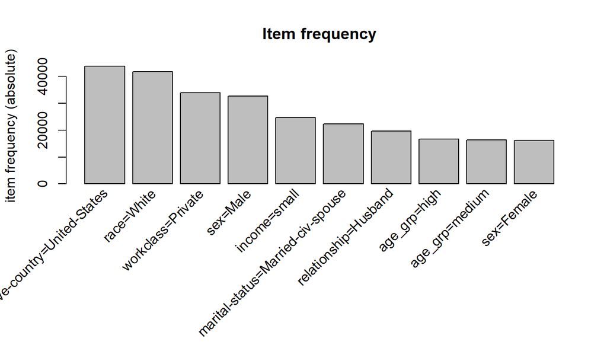

```r
itemFrequencyPlot(adult, topN = 10, type = "absolute", main = "Item frequency")
```

## Sort Association Rules by Performance Metrics

```r
rules <- apriori(adult, parameter = list(support = 0.1, confidence = 0.5))
```

```r
quality(head(rules, 3))
```

```
##     support confidence lift count
## 1 0.5061218  0.5061218    1 24720
## 2 0.6684820  0.6684820    1 32650
## 3 0.6941976  0.6941976    1 33906
```

```r
inspect(head(sort(rules, by = "lift", decreasing = T), 8))
```

```
##     lhs                               rhs                              support confidence     lift count
## [1] {marital-status=Never-married,
##      native-country=United-States,
##      age_grp=low}                  => {relationship=Own-child}       0.1123828  0.5414817 3.488596  5489
## [2] {marital-status=Never-married,
##      race=White,
##      age_grp=low}                  => {relationship=Own-child}       0.1029442  0.5327964 3.432640  5028
## [3] {marital-status=Never-married,
##      age_grp=low}                  => {relationship=Own-child}       0.1209410  0.5233918 3.372049  5907
## [4] {relationship=Own-child,
##      race=White,
##      age_grp=low}                  => {marital-status=Never-married} 0.1029442  0.9501134 2.879285  5028
## [5] {relationship=Own-child,
##      native-country=United-States,
##      age_grp=low}                  => {marital-status=Never-married} 0.1123828  0.9498183 2.878391  5489
## [6] {relationship=Own-child,
##      age_grp=low}                  => {marital-status=Never-married} 0.1209410  0.9470899 2.870123  5907
## [7] {marital-status=Never-married,
##      relationship=Own-child,
##      race=White}                   => {age_grp=low}                  0.1029442  0.8811777 2.725162  5028
## [8] {relationship=Own-child,
##      race=White,
##      native-country=United-States} => {marital-status=Never-married} 0.1106630  0.8976914 2.720422  5405
```

## Remove redundant rules

- In the presence of more general rules, the specific rules are considered as redundant and should be removed
  - Example: {human} => {mammal} vs. {human, male} => {mammal}

```r
subset_rules <- which(colSums(is.subset(rules, rules)) > 1)
rules <- sort(rules[-subset_rules], by = "lift", descreasing = T)
inspect(head(rules, 5))
```

```
##     lhs                             rhs                                   support confidence     lift count
## [1] {relationship=Own-child}     => {marital-status=Never-married}      0.1382007  0.8903839 2.698277  6750
## [2] {relationship=Own-child}     => {age_grp=low}                       0.1276975  0.8227147 2.544357  6237
## [3] {income=large}               => {relationship=Husband}              0.1211662  0.7547507 1.869727  5918
## [4] {income=large}               => {marital-status=Married-civ-spouse} 0.1370132  0.8534626 1.862676  6692
## [5] {relationship=Not-in-family} => {marital-status=Never-married}      0.1456533  0.5653660 1.713322  7114
```

## Use Association Rule Mining as a Supervised Learning Method

Force the target classification attribute on RHS of association rules

```r
rules <- apriori(data = adult, parameter = list(supp = 0.01, conf = 0.5),
                 appearance = list(default = "lhs", rhs = c("income=small", "income=large")),
                 control = list(verbose = F))
inspect(head(sort(rules, by = "lift", descreasing = T), 3))
```

```
##     lhs                                    rhs               support confidence     lift count
## [1] {education=Bachelors,
##      occupation=Exec-managerial,
##      relationship=Husband}              => {income=large} 0.01250973  0.5431111 3.383068   611
## [2] {education=Bachelors,
##      marital-status=Married-civ-spouse,
##      occupation=Exec-managerial,
##      relationship=Husband}              => {income=large} 0.01250973  0.5431111 3.383068   611
## [3] {education=Bachelors,
##      occupation=Exec-managerial,
##      relationship=Husband,
##      sex=Male}                          => {income=large} 0.01250973  0.5431111 3.383068   611
```

## Plot Association Rules on Selected Metrics Dimensions

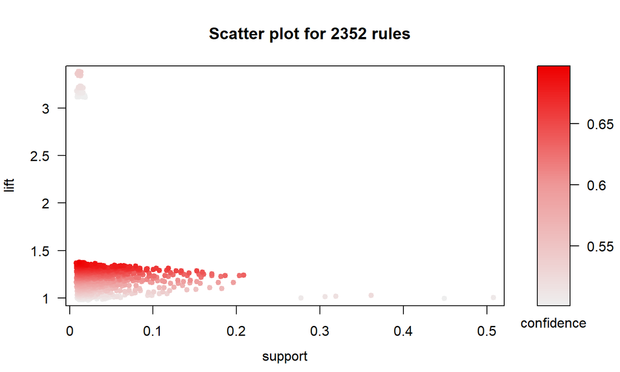

```r
plot(rules, measure = c("support", "lift"), shading = "confidence")
```

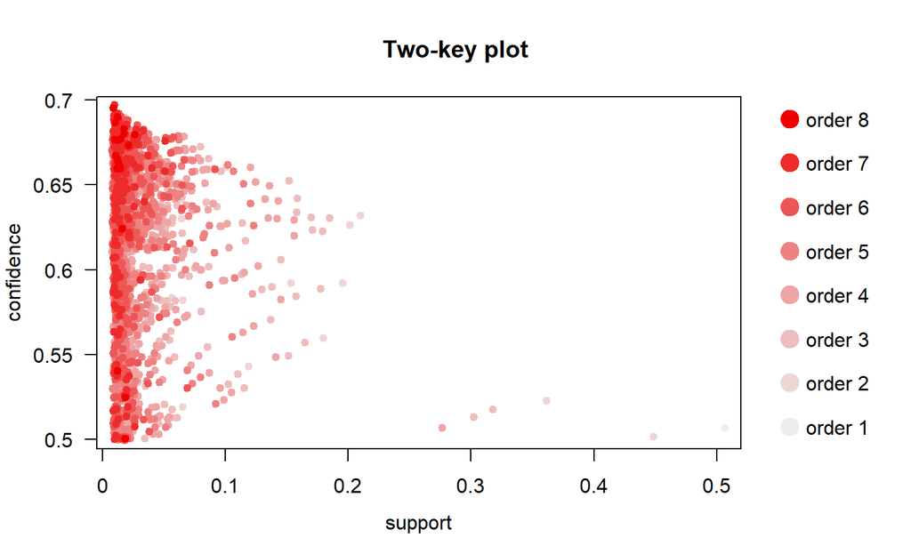

[output not shown]

```r
plot(rules, shading = "order", control = list(main = "Two-key plot"))
```

## Demo in Python: Import Libraries

```python
import matplotlib.pyplot as plt
import numpy as np
import pandas as pd
from pandas import DataFrame, Series
import seaborn as sns
import apyori as ap
from apyori import apriori #Apriori Algorithm
import mlxtend as ml
from mlxtend.frequent_patterns import apriori
from mlxtend.frequent_patterns import association_rules
from mlxtend.preprocessing import TransactionEncoder
```

## Read Data into Pandas Data Frame

```python
AdultUCIdata = pd.read_csv("http://archive.ics.uci.edu/ml/machine-learning-databases/adult/adult.data",
               sep=",", names=["age", "type_employer", "fnlwgt", "education",
               "education_num", "marital", "occupation", "relationship", "race","sex",
               "capital_gain", "capital_loss", "hr_per_week", "country", "income"])

AdultUCIdata.head()
```

```
##    age      type_employer  fnlwgt  ... hr_per_week         country  income
## 0   39          State-gov   77516  ...          40   United-States   <=50K
## 1   50   Self-emp-not-inc   83311  ...          13   United-States   <=50K
## 2   38            Private  215646  ...          40   United-States   <=50K
## 3   53            Private  234721  ...          40   United-States   <=50K
## 4   28            Private  338409  ...          40            Cuba   <=50K
##
## [5 rows x 15 columns]
```

## Discretize Numerical Attributes

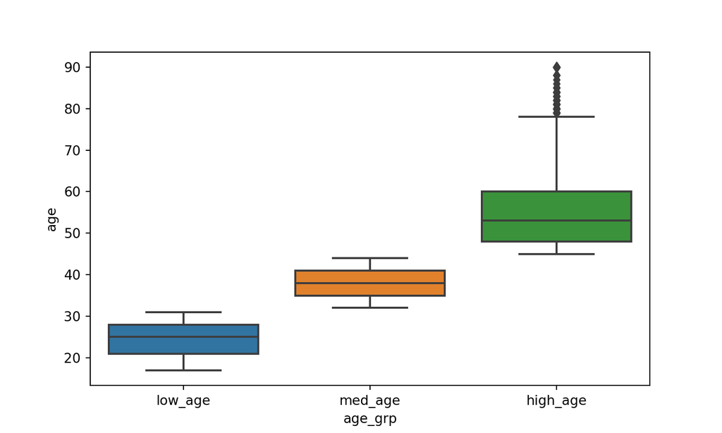

```python
AdultUCIdata["age_grp"] = pd.qcut(AdultUCIdata.age, 3,
                                  labels = ['low_age','med_age','high_age'])
AdultUCIdata["capitalgain_grp"] = pd.cut(AdultUCIdata.capital_gain, 2,
                                         labels = ['low_gain','high_gain'])
AdultUCIdata["capitalloss_grp"] = pd.cut(AdultUCIdata.capital_loss, 2,
                                         labels = ['low_loss','high_loss'])
AdultUCIdata["hr_perweek_grp"] = pd.cut(AdultUCIdata.hr_per_week, [0, 39, 45, 80],
                                        labels = ['low_hr','normal_hr','high_hr'])

sns.boxplot(x='age_grp',y='age',data=AdultUCIdata)
```

## Prepare Dataset for Association Rule Mining

```python
AdultUCIdata = AdultUCIdata.astype('str')
AdultUCIdata.loc[:,['age', 'age_grp', 'capital_gain', 'capitalgain_grp',
                    'hr_per_week', 'hr_perweek_grp']].head(5)
AdultUCIdata[AdultUCIdata.columns] = AdultUCIdata.apply(lambda x: x.str.strip())
AdultUCIdata = AdultUCIdata.astype('object')
AdultUCIdata2 = AdultUCIdata.drop(['age', 'capital_gain', 'hr_per_week',
                                   'capital_loss', 'fnlwgt'], axis=1)
AdultUCIdata3 = AdultUCIdata2[AdultUCIdata['country'] == 'United-States']
AdultUCIdata4 = pd.DataFrame({col: str(col)+'=' for col in AdultUCIdata3}, index=AdultUCIdata3.index) + AdultUCIdata3.astype(str)
AdultUCIdata4.head()
```

```
##   age   age_grp capital_gain capitalgain_grp hr_per_week hr_perweek_grp
## 0  39   med_age         2174        low_gain          40      normal_hr
## 1  50  high_age            0        low_gain          13         low_hr
## 2  38   med_age            0        low_gain          40      normal_hr
## 3  53  high_age            0        low_gain          40      normal_hr
## 4  28   low_age            0        low_gain          40      normal_hr
```

```
##                     type_employer  ...            hr_perweek_grp
## 0         type_employer=State-gov  ...  hr_perweek_grp=normal_hr
## 1  type_employer=Self-emp-not-inc  ...     hr_perweek_grp=low_hr
## 2           type_employer=Private  ...  hr_perweek_grp=normal_hr
## 3           type_employer=Private  ...  hr_perweek_grp=normal_hr
## 5           type_employer=Private  ...  hr_perweek_grp=normal_hr
##
## [5 rows x 14 columns]
```

## Visualize Frequent Itemsets

[output not shown]

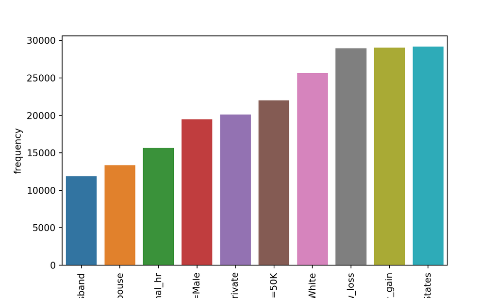

```python
melted_data = pd.melt(AdultUCIdata4)
melted_data.head()
frequency = melted_data.groupby(by=['value'])['value'].count().sort_values(ascending=True)
freq_itemset = pd.DataFrame({'item':frequency.index, 'frequency':frequency.values})
g = sns.barplot(data=freq_itemset.tail(10), x='item', y='frequency')
g.set_xticklabels(g.get_xticklabels(), rotation=90)
plt.show()
```

## Run APriori with Apyori Library

```python
records = []
for i in range(0,len(AdultUCIdata4)):
    records.append([str(AdultUCIdata4.values[i,j])
    for j in range(0, len(AdultUCIdata4.columns))])
frequent_itemset = ap.apriori(records, min_support=0.8, min_confidence=0.8,
                              min_lift=1,min_length=2)
results = list(frequent_itemset)
len(results)
results[1:5]
```

```
## 11
```

[output not shown]

## Use Association Rules from Mlxtend Library

```python
te = TransactionEncoder()
te_ary = te.fit(records).transform(records)
df = pd.DataFrame(te_ary, columns=te.columns_)
frequent_itemsets = apriori(df, min_support=0.5, use_colnames=True)
frequent_itemsets.sort_values(by='support',ascending=False).head(10)
rules = association_rules(frequent_itemsets, metric="lift", min_threshold=1)
rules.head()
rules[(rules['lift']>1) & (rules['confidence'] > 0.8)].head(10)
```

```
##      support                                           itemsets
## 2   1.000000                            (country=United-States)
## 0   0.995132                         (capitalgain_grp=low_gain)
## 9   0.995132  (capitalgain_grp=low_gain, country=United-States)
## 15  0.993007  (country=United-States, capitalloss_grp=low_loss)
## 1   0.993007                         (capitalloss_grp=low_loss)
## 30  0.988138  (capitalgain_grp=low_gain, country=United-Stat...
## 8   0.988138  (capitalgain_grp=low_gain, capitalloss_grp=low...
## 5   0.878334                                       (race=White)
## 23  0.878334                (race=White, country=United-States)
## 12  0.873740             (race=White, capitalgain_grp=low_gain)
```

```
##                   antecedents                 consequents  ...  leverage  conviction
## 0  (capitalgain_grp=low_gain)     (country=United-States)  ...  0.000000         inf
## 1     (country=United-States)  (capitalgain_grp=low_gain)  ...  0.000000    1.000000
## 2  (capitalgain_grp=low_gain)  (hr_perweek_grp=normal_hr)  ...  0.001176    1.002560
## 3  (hr_perweek_grp=normal_hr)  (capitalgain_grp=low_gain)  ...  0.001176    1.816581
## 4  (capitalgain_grp=low_gain)              (income=<=50K)  ...  0.003671    1.015236
##
## [5 rows x 9 columns]
```

```
##                                           antecedents  ... conviction
## 3                          (hr_perweek_grp=normal_hr)  ...   1.816581
## 5                                      (income=<=50K)  ...        inf
## 7                             (type_employer=Private)  ...   1.324561
## 10                         (hr_perweek_grp=normal_hr)  ...   1.141760
## 12                                     (income=<=50K)  ...   1.899379
## 14                            (type_employer=Private)  ...   1.316017
## 29                                         (sex=Male)  ...   1.292114
## 31                            (type_employer=Private)  ...   1.017759
## 34  (capitalgain_grp=low_gain, hr_perweek_grp=norm...  ...   1.138700
## 36  (hr_perweek_grp=normal_hr, capitalloss_grp=low...  ...   1.805454
##
## [10 rows x 9 columns]
```

## Plot Association Rules

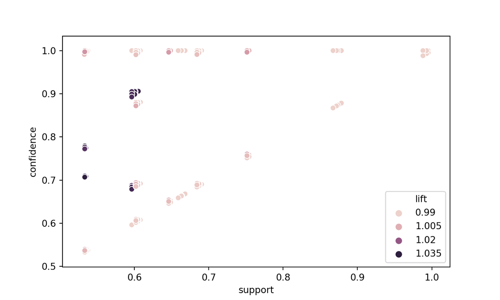

```python
b = sns.scatterplot(data=rules,x='support',y='confidence',hue='lift')
plt.show()
```

## Classification with Association Rule Mining

```python
def SupervisedApriori(data,consequent,min_supp,min_conf,min_lift):
    frequent_itemsets = apriori(data, min_supp, use_colnames=True)
    rules = association_rules(frequent_itemsets, metric="confidence", min_threshold=min_conf)
    #filter according to lift
    rules = rules[rules['lift'] > min_lift]
    sup_rules = pd.DataFrame()
    for i in consequent:
        df = rules[rules['consequents'] == {i}]
        sup_rules = sup_rules.append(df,ignore_index = True)
    return(sup_rules)

SupervisedApriori(df,consequent = ['income=>50K','income=<=50K'],
min_supp=0.04, min_conf=0.7, min_lift=2).sort_values(by='support',ascending=False).head(5)
```

[output not shown]